# A Video Game Analysis

Moutafidis Christos

2024-02-10

Hello, this case study is about Video game sales and the Critic/User score, I Downloaded the Data base from a kaggle user named: **DIMA806**. This data set contains data from 2016, so the results may vary from todays standars.

## Videogame Sales and Scores

First we start by installing the necessary packages.

```r
library(tidyverse)
```

```r
library(ggplot2)
library(dplyr)
```

Then,I would for like you all to see the data set. (The first 10 rows of the data set)

```r
Video_Games <- read.csv("Video_Games_Sales_as_at_22_Dec_2016.csv")
head(Video_Games, 10)
```

```
##                         Name Platform Year_of_Release        Genre Publisher
## 1                 Wii Sports      Wii            2006       Sports  Nintendo
## 2          Super Mario Bros.      NES            1985     Platform  Nintendo
## 3             Mario Kart Wii      Wii            2008       Racing  Nintendo
## 4          Wii Sports Resort      Wii            2009       Sports  Nintendo
## 5   Pokemon Red/Pokemon Blue       GB            1996 Role-Playing  Nintendo
## 6                     Tetris       GB            1989       Puzzle  Nintendo
## 7      New Super Mario Bros.       DS            2006     Platform  Nintendo
## 8                   Wii Play      Wii            2006         Misc  Nintendo
## 9  New Super Mario Bros. Wii      Wii            2009     Platform  Nintendo
## 10                 Duck Hunt      NES            1984      Shooter  Nintendo
##    NA_Sales EU_Sales JP_Sales Other_Sales Global_Sales Critic_Score
## 1     41.36    28.96     3.77        8.45        82.53           76
## 2     29.08     3.58     6.81        0.77        40.24           NA
## 3     15.68    12.76     3.79        3.29        35.52           82
```

[output cut: 18 more lines]

Now, to starting the analysis, my first step was to see all the column names.

```r
colnames(Video_Games)
```

```
##  [1] "Name"            "Platform"        "Year_of_Release" "Genre"
##  [5] "Publisher"       "NA_Sales"        "EU_Sales"        "JP_Sales"
##  [9] "Other_Sales"     "Global_Sales"    "Critic_Score"    "Critic_Count"
## [13] "User_Score"      "User_Count"      "Developer"       "Rating"
```

Now that we have the Column names, we can start by finding what we think that is important for the audience to see, for my analysis I wanted to find the: 1. Best selling Platform of all time.(the platform that has sold the most games) 2. Best selling game per Platform. 3. Best selling Genres. 4. Best selling games in those Genres. 5. Best User Scored Game. 6. Best Critic’s Scored Game. 7. Most Sold Video game of all time.

Let us begin then.

I start by Viewing the best **Genres** (I want to keep the Most sold Video game for last).

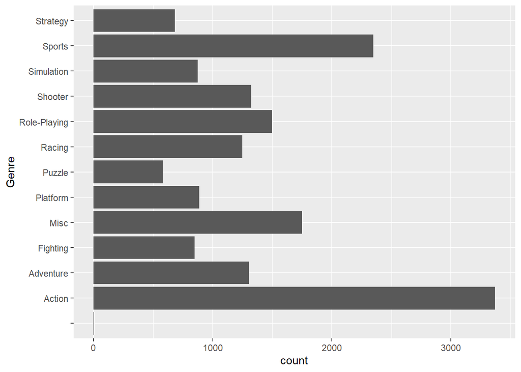

```r
ggplot(data = Video_Games) + geom_bar(mapping = aes(y= Genre))
```

From this plot we can Visualize the top **Genres**. 1. Action. 2. Sports. 3. Misc. 4. Role_Playing(AKA RPG). 5. Shooters

## Now lets find the Best sellers per Gaming Genre.

Let us start with the **Action** Genre:

```r
Action_G <- Video_Games
Action_G <- filter(Video_Games,Genre=="Action") #setting the data set, and filtering the data
Action_G <- head(arrange(Action_G, desc(Global_Sales)),5) #arranging the data within the data set
head(Action_G)
```

```
##                            Name Platform Year_of_Release  Genre
## 1            Grand Theft Auto V      PS3            2013 Action
## 2 Grand Theft Auto: San Andreas      PS2            2004 Action
## 3            Grand Theft Auto V     X360            2013 Action
## 4   Grand Theft Auto: Vice City      PS2            2002 Action
## 5          Grand Theft Auto III      PS2            2001 Action
##              Publisher NA_Sales EU_Sales JP_Sales Other_Sales Global_Sales
## 1 Take-Two Interactive     7.02     9.09     0.98        3.96        21.04
## 2 Take-Two Interactive     9.43     0.40     0.41       10.57        20.81
## 3 Take-Two Interactive     9.66     5.14     0.06        1.41        16.27
## 4 Take-Two Interactive     8.41     5.49     0.47        1.78        16.15
## 5 Take-Two Interactive     6.99     4.51     0.30        1.30        13.10
##   Critic_Score Critic_Count User_Score User_Count      Developer Rating
## 1           97           50        8.2       3994 Rockstar North      M
## 2           95           80        9.0       1588 Rockstar North      M
## 3           97           58        8.1       3711 Rockstar North      M
## 4           95           62        8.7        730 Rockstar North      M
## 5           97           56        8.5        664     DMA Design      M
```

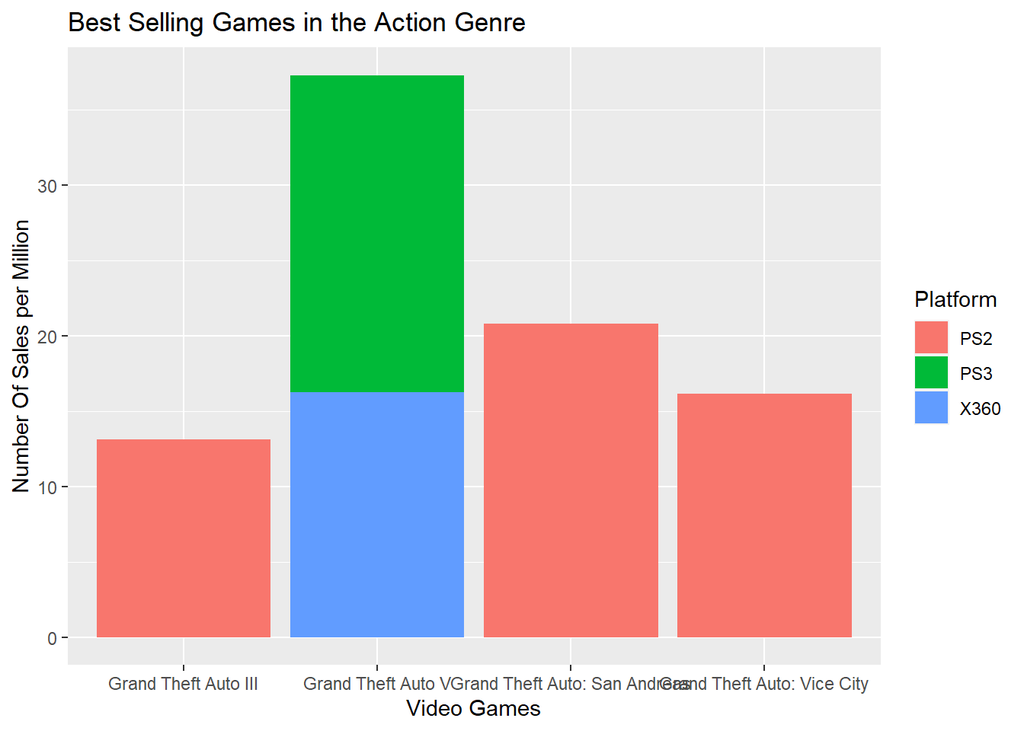

```r
ggplot(data = Action_G) +geom_col(mapping = aes(y=Global_Sales,x=Name,  fill = Platform)) + labs(title = "Best Selling Games in the Action Genre",x="Video Games", y = "Number Of Sales per Million")
```

Same goes for the rest:

```r
Sports_G <- Video_Games
Sports_G <- filter(Video_Games,Genre=="Sports") #setting the data set, and filtering the data
Sports_G <- head(arrange(Sports_G, desc(Global_Sales)),5) #arranging the data within the data set
head(Sports_G)
```

```
##                Name Platform Year_of_Release  Genre       Publisher NA_Sales
## 1        Wii Sports      Wii            2006 Sports        Nintendo    41.36
## 2 Wii Sports Resort      Wii            2009 Sports        Nintendo    15.61
## 3           Wii Fit      Wii            2007 Sports        Nintendo     8.92
## 4      Wii Fit Plus      Wii            2009 Sports        Nintendo     9.01
## 5           FIFA 16      PS4            2015 Sports Electronic Arts     1.12
##   EU_Sales JP_Sales Other_Sales Global_Sales Critic_Score Critic_Count
## 1    28.96     3.77        8.45        82.53           76           51
## 2    10.93     3.28        2.95        32.77           80           73
## 3     8.03     3.60        2.15        22.70           80           63
## 4     8.49     2.53        1.77        21.79           80           33
## 5     6.12     0.06        1.28         8.57           82           42
##   User_Score User_Count Developer Rating
## 1        8.0        322  Nintendo      E
## 2        8.0        192  Nintendo      E
## 3        7.7        146  Nintendo      E
## 4        7.4         52  Nintendo      E
## 5        4.3        896 EA Sports      E
```

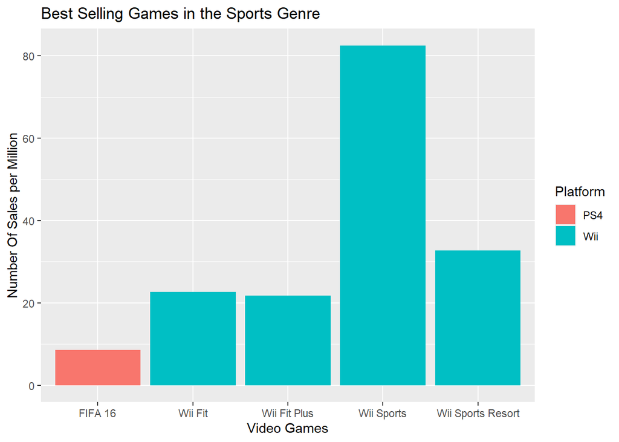

```r
ggplot(data = Sports_G) +geom_col(mapping = aes(y=Global_Sales,x=Name,  fill = Platform)) + labs(title = "Best Selling Games in the Sports Genre",x="Video Games", y = "Number Of Sales per Million")
```

```r
Misc_G <- Video_Games
Misc_G <- filter(Video_Games,Genre=="Misc") #setting the data set, and filtering the data
Misc_G <- head(arrange(Misc_G, desc(Global_Sales)),5) #arranging the data within the data set
head(Misc_G)
```

```
##                                           Name Platform Year_of_Release Genre
## 1                                     Wii Play      Wii            2006  Misc
## 2                           Kinect Adventures!     X360            2010  Misc
## 3 Brain Age: Train Your Brain in Minutes a Day       DS            2005  Misc
## 4                                 Just Dance 3      Wii            2011  Misc
## 5                                 Just Dance 2      Wii            2010  Misc
##                Publisher NA_Sales EU_Sales JP_Sales Other_Sales Global_Sales
## 1               Nintendo    13.96     9.18     2.93        2.84        28.92
## 2 Microsoft Game Studios    15.00     4.89     0.24        1.69        21.81
## 3               Nintendo     4.74     9.20     4.16        2.04        20.15
## 4                Ubisoft     5.95     3.11     0.00        1.06        10.12
## 5                Ubisoft     5.80     2.85     0.01        0.78         9.44
##   Critic_Score Critic_Count User_Score User_Count           Developer Rating
## 1           58           41        6.6        129            Nintendo      E
## 2           61           45        6.3        106 Good Science Studio      E
## 3           77           58        7.9         50            Nintendo      E
## 4           74           15        7.8         16             Ubisoft   E10+
## 5           74           24        7.3         24             Ubisoft   E10+
```

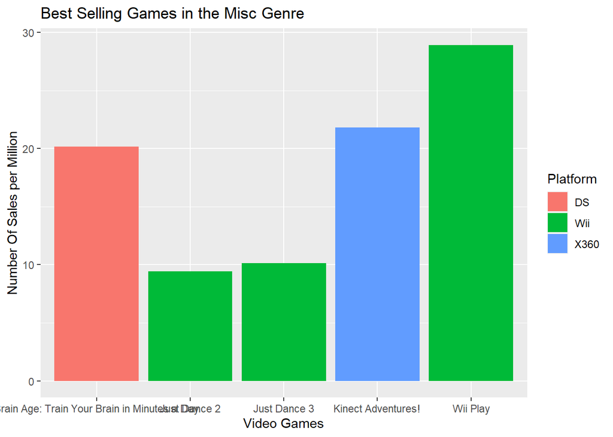

```r
ggplot(data = Misc_G) +geom_col(mapping = aes(y=Global_Sales,x=Name,  fill = Platform)) + labs(title = "Best Selling Games in the Misc Genre",x="Video Games", y = "Number Of Sales per Million")
```

```r
RPG_G <- Video_Games
RPG_G <- filter(Video_Games,Genre=="Role-Playing") #setting the data set, and filtering the data
RPG_G <- head(arrange(RPG_G, desc(Global_Sales)),5) #arranging the data within the data set
head(RPG_G)
```

```
##                            Name Platform Year_of_Release        Genre Publisher
## 1      Pokemon Red/Pokemon Blue       GB            1996 Role-Playing  Nintendo
## 2   Pokemon Gold/Pokemon Silver       GB            1999 Role-Playing  Nintendo
## 3 Pokemon Diamond/Pokemon Pearl       DS            2006 Role-Playing  Nintendo
## 4 Pokemon Ruby/Pokemon Sapphire      GBA            2002 Role-Playing  Nintendo
## 5   Pokemon Black/Pokemon White       DS            2010 Role-Playing  Nintendo
##   NA_Sales EU_Sales JP_Sales Other_Sales Global_Sales Critic_Score Critic_Count
## 1    11.27     8.89    10.22        1.00        31.37           NA           NA
## 2     9.00     6.18     7.20        0.71        23.10           NA           NA
## 3     6.38     4.46     6.04        1.36        18.25           NA           NA
## 4     6.06     3.90     5.38        0.50        15.85           NA           NA
## 5     5.51     3.17     5.65        0.80        15.14           NA           NA
##   User_Score User_Count Developer Rating
## 1         NA         NA
## 2         NA         NA
## 3         NA         NA
## 4         NA         NA
## 5         NA         NA
```

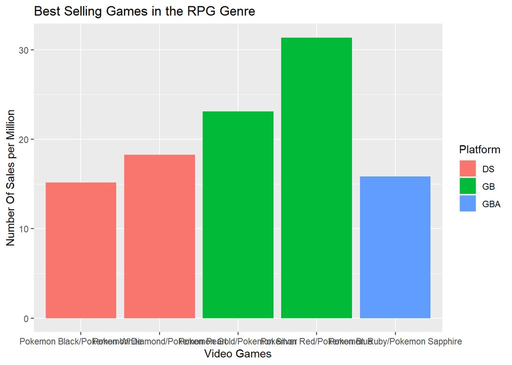

```r
ggplot(data = RPG_G) +geom_col(mapping = aes(y=Global_Sales,x=Name,  fill = Platform)) + labs(title = "Best Selling Games in the RPG Genre", x="Video Games", y = "Number Of Sales per Million")
```

```r
Shooter_G <- Video_Games
Shooter_G <- filter(Video_Games,Genre=="Shooter") #setting the data set, and filtering the data
Shooter_G <- head(arrange(Shooter_G, desc(Global_Sales)),5) #arranging the data within the data set
head(Shooter_G)
```

```
##                             Name Platform Year_of_Release   Genre  Publisher
## 1                      Duck Hunt      NES            1984 Shooter   Nintendo
## 2 Call of Duty: Modern Warfare 3     X360            2011 Shooter Activision
## 3      Call of Duty: Black Ops 3      PS4            2015 Shooter Activision
## 4        Call of Duty: Black Ops     X360            2010 Shooter Activision
## 5     Call of Duty: Black Ops II      PS3            2012 Shooter Activision
##   NA_Sales EU_Sales JP_Sales Other_Sales Global_Sales Critic_Score Critic_Count
## 1    26.93     0.63     0.28        0.47        28.31           NA           NA
## 2     9.04     4.24     0.13        1.32        14.73           88           81
## 3     6.03     5.86     0.36        2.38        14.63           NA           NA
## 4     9.70     3.68     0.11        1.13        14.61           87           89
## 5     4.99     5.73     0.65        2.42        13.79           83           21
##   User_Score User_Count                         Developer Rating
## 1         NA         NA
## 2        3.4       8713 Infinity Ward, Sledgehammer Games      M
## 3         NA         NA
## 4        6.3       1454                          Treyarch      M
## 5        5.3        922                          Treyarch      M
```

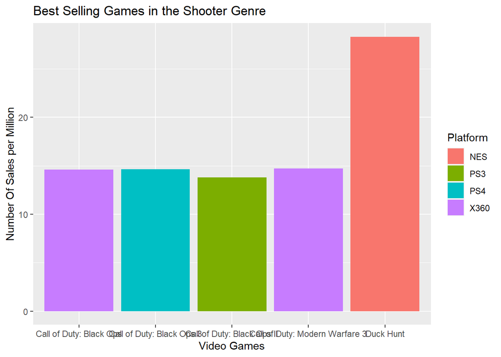

```r
ggplot(data = Shooter_G) +geom_col(mapping = aes(y=Global_Sales,x=Name,  fill = Platform)) + labs(title = "Best Selling Games in the Shooter Genre",x="Video Games", y = "Number Of Sales per Million")
```

Would you look at that? Duck Hunt is the Most sold Shooter in the world…Huh.

Now let us do a quick recap: 1. Best selling Platform of all time.(the platform that has sold the most games) 2. Best selling game per Platform. 3. Best selling Genres. **DONE** 4. Best selling games in those Genres. **DONE** 5. Best User Scored Game. 6. Best Critic’s Scored Game. 7. Most Sold Video game of all time.

### Now lets find the best selling Platforms:

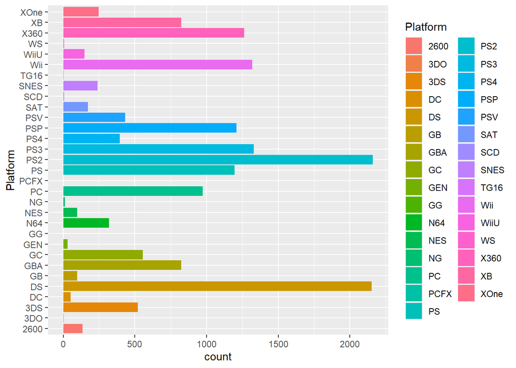

```r
ggplot(data = Video_Games) + geom_bar(mapping = aes(y=Platform, fill = Platform))
```

And with this we find the best selling **Platforms**: 1. PlayStation 2, 2. Nintendo DS, 3. Playstation 3, 4. Nintendo Wii, 5. Xbox 360.

## Time to find the best selling games per platform.

```r
PS2_plat <- Video_Games
PS2_plat <- filter(Video_Games,Platform=="PS2") #setting the data set, and filtering the data
PS2_plat <- head(arrange(PS2_plat, desc(Global_Sales)),5) #arranging the data within the data set
head(PS2_plat)
```

```
##                            Name Platform Year_of_Release  Genre
## 1 Grand Theft Auto: San Andreas      PS2            2004 Action
## 2   Grand Theft Auto: Vice City      PS2            2002 Action
## 3        Gran Turismo 3: A-Spec      PS2            2001 Racing
## 4          Grand Theft Auto III      PS2            2001 Action
## 5                Gran Turismo 4      PS2            2004 Racing
##                     Publisher NA_Sales EU_Sales JP_Sales Other_Sales
## 1        Take-Two Interactive     9.43     0.40     0.41       10.57
## 2        Take-Two Interactive     8.41     5.49     0.47        1.78
## 3 Sony Computer Entertainment     6.85     5.09     1.87        1.16
## 4        Take-Two Interactive     6.99     4.51     0.30        1.30
## 5 Sony Computer Entertainment     3.01     0.01     1.10        7.53
##   Global_Sales Critic_Score Critic_Count User_Score User_Count
## 1        20.81           95           80        9.0       1588
## 2        16.15           95           62        8.7        730
## 3        14.98           95           54        8.4        314
## 4        13.10           97           56        8.5        664
## 5        11.66           89           74        8.5        272
##           Developer Rating
## 1    Rockstar North      M
## 2    Rockstar North      M
## 3 Polyphony Digital      E
## 4        DMA Design      M
## 5 Polyphony Digital      E
```

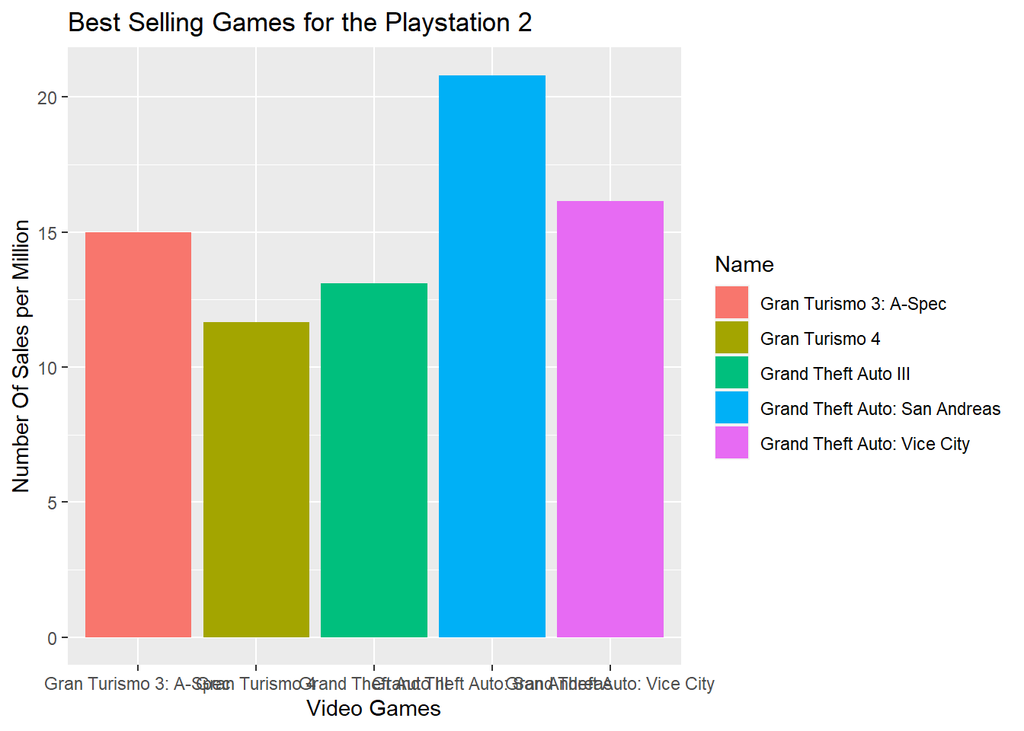

```r
ggplot(data = PS2_plat) +geom_col(mapping = aes(y=Global_Sales,x=Name,  fill = Name)) + labs(title = "Best Selling Games for the Playstation 2",x="Video Games", y = "Number Of Sales per Million")
```

```r
DS_plat <- Video_Games
DS_plat <- filter(Video_Games,Platform=="DS") #setting the data set, and filtering the data
DS_plat <- head(arrange(DS_plat, desc(Global_Sales)),5) #arranging the data within the data set
head(DS_plat)
```

```
##                                           Name Platform Year_of_Release
## 1                        New Super Mario Bros.       DS            2006
## 2                                   Nintendogs       DS            2005
## 3                                Mario Kart DS       DS            2005
## 4 Brain Age: Train Your Brain in Minutes a Day       DS            2005
## 5                Pokemon Diamond/Pokemon Pearl       DS            2006
##          Genre Publisher NA_Sales EU_Sales JP_Sales Other_Sales Global_Sales
## 1     Platform  Nintendo    11.28     9.14     6.50        2.88        29.80
## 2   Simulation  Nintendo     9.05    10.95     1.93        2.74        24.67
## 3       Racing  Nintendo     9.71     7.47     4.13        1.90        23.21
## 4         Misc  Nintendo     4.74     9.20     4.16        2.04        20.15
## 5 Role-Playing  Nintendo     6.38     4.46     6.04        1.36        18.25
##   Critic_Score Critic_Count User_Score User_Count Developer Rating
## 1           89           65        8.5        431  Nintendo      E
## 2           NA           NA         NA         NA
## 3           91           64        8.6        464  Nintendo      E
## 4           77           58        7.9         50  Nintendo      E
## 5           NA           NA         NA         NA
```

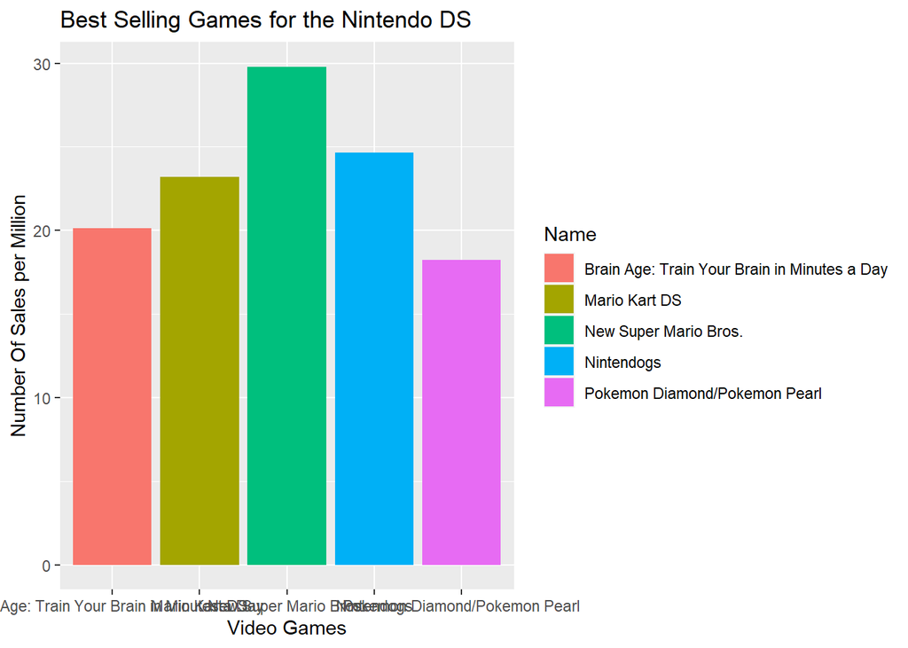

```r
ggplot(data = DS_plat) +geom_col(mapping = aes(y=Global_Sales,x=Name,  fill = Name)) + labs(title = "Best Selling Games for the Nintendo DS",x="Video Games", y = "Number Of Sales per Million")
```

```r
PS3_plat <- Video_Games
PS3_plat <- filter(Video_Games,Platform=="PS3") #setting the data set, and filtering the data
PS3_plat <- head(arrange(PS3_plat, desc(Global_Sales)),5) #arranging the data within the data set
head(PS3_plat)
```

```
##                             Name Platform Year_of_Release   Genre
## 1             Grand Theft Auto V      PS3            2013  Action
## 2     Call of Duty: Black Ops II      PS3            2012 Shooter
## 3 Call of Duty: Modern Warfare 3      PS3            2011 Shooter
## 4        Call of Duty: Black Ops      PS3            2010 Shooter
## 5                 Gran Turismo 5      PS3            2010  Racing
##                     Publisher NA_Sales EU_Sales JP_Sales Other_Sales
## 1        Take-Two Interactive     7.02     9.09     0.98        3.96
## 2                  Activision     4.99     5.73     0.65        2.42
## 3                  Activision     5.54     5.73     0.49        1.57
## 4                  Activision     5.99     4.37     0.48        1.79
## 5 Sony Computer Entertainment     2.96     4.82     0.81        2.11
##   Global_Sales Critic_Score Critic_Count User_Score User_Count
## 1        21.04           97           50        8.2       3994
## 2        13.79           83           21        5.3        922
## 3        13.32           88           39        3.2       5234
## 4        12.63           88           58        6.4       1094
## 5        10.70           84           82        7.5       1112
##                           Developer Rating
## 1                    Rockstar North      M
## 2                          Treyarch      M
## 3 Infinity Ward, Sledgehammer Games      M
## 4                          Treyarch      M
## 5                 Polyphony Digital      E
```

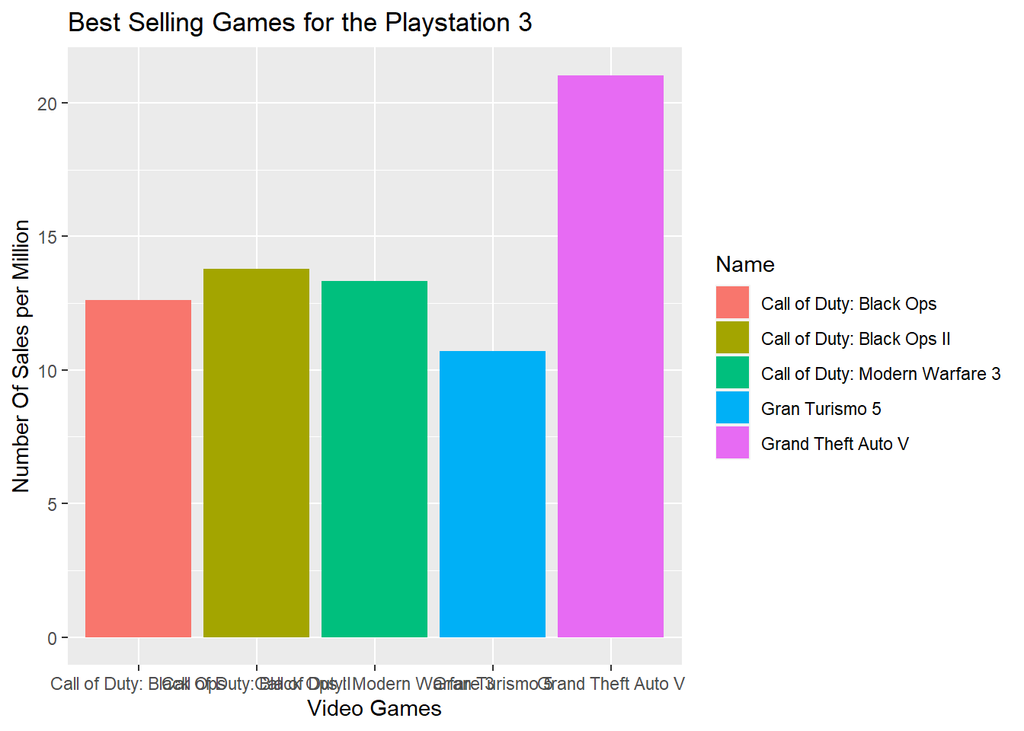

```r
ggplot(data = PS3_plat) +geom_col(mapping = aes(y=Global_Sales,x=Name,  fill = Name)) + labs(title = "Best Selling Games for the Playstation 3",x="Video Games", y = "Number Of Sales per Million")
```

```r
Wii_plat <- Video_Games
Wii_plat <- filter(Video_Games,Platform=="Wii") #setting the data set, and filtering the data
Wii_plat <- head(arrange(Wii_plat, desc(Global_Sales)),5) #arranging the data within the data set
head(Wii_plat)
```

```
##                        Name Platform Year_of_Release    Genre Publisher
## 1                Wii Sports      Wii            2006   Sports  Nintendo
## 2            Mario Kart Wii      Wii            2008   Racing  Nintendo
## 3         Wii Sports Resort      Wii            2009   Sports  Nintendo
## 4                  Wii Play      Wii            2006     Misc  Nintendo
## 5 New Super Mario Bros. Wii      Wii            2009 Platform  Nintendo
##   NA_Sales EU_Sales JP_Sales Other_Sales Global_Sales Critic_Score Critic_Count
## 1    41.36    28.96     3.77        8.45        82.53           76           51
## 2    15.68    12.76     3.79        3.29        35.52           82           73
## 3    15.61    10.93     3.28        2.95        32.77           80           73
## 4    13.96     9.18     2.93        2.84        28.92           58           41
## 5    14.44     6.94     4.70        2.24        28.32           87           80
##   User_Score User_Count Developer Rating
## 1        8.0        322  Nintendo      E
## 2        8.3        709  Nintendo      E
## 3        8.0        192  Nintendo      E
## 4        6.6        129  Nintendo      E
## 5        8.4        594  Nintendo      E
```

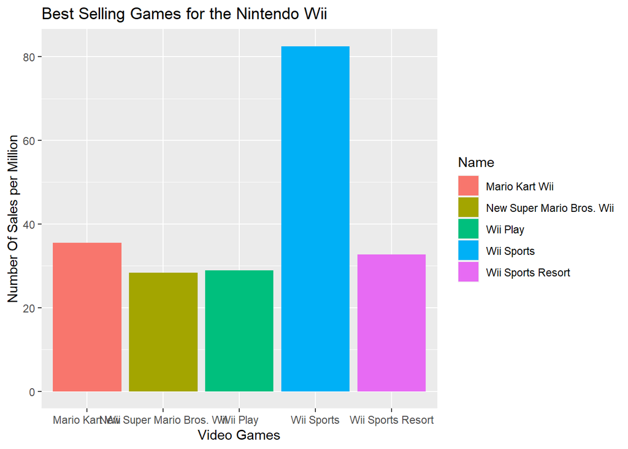

```r
ggplot(data = Wii_plat) +geom_col(mapping = aes(y=Global_Sales,x=Name,  fill = Name)) + labs(title = "Best Selling Games for the Nintendo Wii",x="Video Games", y = "Number Of Sales per Million")
```

**And Last but not least**

```r
X360_plat <- Video_Games
X360_plat <- filter(Video_Games,Platform=="X360") #setting the data set, and filtering the data
X360_plat <- head(arrange(X360_plat, desc(Global_Sales)),5) #arranging the data within the data set
head(X360_plat)
```

```
##                             Name Platform Year_of_Release   Genre
## 1             Kinect Adventures!     X360            2010    Misc
## 2             Grand Theft Auto V     X360            2013  Action
## 3 Call of Duty: Modern Warfare 3     X360            2011 Shooter
## 4        Call of Duty: Black Ops     X360            2010 Shooter
## 5     Call of Duty: Black Ops II     X360            2012 Shooter
##                Publisher NA_Sales EU_Sales JP_Sales Other_Sales Global_Sales
## 1 Microsoft Game Studios    15.00     4.89     0.24        1.69        21.81
## 2   Take-Two Interactive     9.66     5.14     0.06        1.41        16.27
## 3             Activision     9.04     4.24     0.13        1.32        14.73
## 4             Activision     9.70     3.68     0.11        1.13        14.61
## 5             Activision     8.25     4.24     0.07        1.12        13.67
##   Critic_Score Critic_Count User_Score User_Count
## 1           61           45        6.3        106
## 2           97           58        8.1       3711
## 3           88           81        3.4       8713
## 4           87           89        6.3       1454
## 5           83           73        4.8       2256
##                           Developer Rating
## 1               Good Science Studio      E
## 2                    Rockstar North      M
## 3 Infinity Ward, Sledgehammer Games      M
## 4                          Treyarch      M
## 5                          Treyarch      M
```

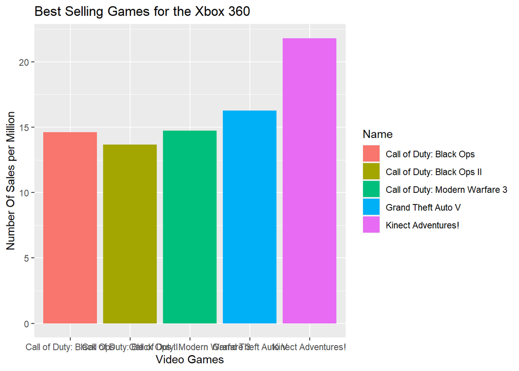

```r
ggplot(data = X360_plat) +geom_col(mapping = aes(y=Global_Sales,x=Name,  fill = Name)) + labs(title = "Best Selling Games for the Xbox 360",x="Video Games", y = "Number Of Sales per Million")
```

A quick recap, again: 1. Best selling Platform of all time.(the platform that has sold the most games) **DONE** 2. Best selling game per Platform. **DONE** 3. Best selling Genres. **DONE** 4. Best selling games in those Genres. **DONE** 5. Best User Scored Game. 6. Best Critic’s Scored Game. 7. Most Sold Video game of all time.

Off to the Best **User** and **Critic** Score

To see the best **User Scored Game** we will have to just *arrange* the data, nothing much.

```r
head(arrange(Video_Games,desc(User_Score)),10)
```

```
##                                     Name Platform Year_of_Release        Genre
## 1                     Breath of Fire III      PSP            2005 Role-Playing
## 2  Harvest Moon: Friends of Mineral Town      GBA            2003   Simulation
## 3        Boktai: The Sun is in Your Hand      GBA            2003 Role-Playing
## 4               Golden Sun: The Lost Age      GBA            2002 Role-Playing
## 5                    MLB SlugFest Loaded      PS2            2004       Sports
## 6                      Cory in the House       DS            2007       Action
## 7                Super Puzzle Fighter II      GBA             N/A       Puzzle
## 8            Wade Hixton's Counter Punch      GBA            2004       Sports
## 9                          Karnaaj Rally      GBA            2003       Racing
## 10                      Metal Gear Solid       PS            1998       Action
##                       Publisher NA_Sales EU_Sales JP_Sales Other_Sales
## 1                        Capcom     0.00     0.02     0.00        0.01
## 2                       Ubisoft     0.34     0.13     0.11        0.01
## 3  Konami Digital Entertainment     0.10     0.04     0.00        0.00
```

[output cut: 29 more lines]

Now if you look closely, you will see that some of the games have less than 10 Users who rated the games, that’s not good! so how do we change it?

```r
Top_Ranked_Games_By_User <- Video_Games
Top_Ranked_Games_By_User <- filter(Top_Ranked_Games_By_User, User_Count > 200)
Top_Ranked_Games_By_User <- arrange(Top_Ranked_Games_By_User, desc(User_Score))
Top_Ranked_Games_By_User <- head(Top_Ranked_Games_By_User,5)
head(Top_Ranked_Games_By_User,5)
```

```
##                                  Name Platform Year_of_Release        Genre
## 1                   Cory in the House       DS            2007       Action
## 2                    Metal Gear Solid       PS            1998       Action
## 3 Paper Mario: The Thousand-Year Door       GC            2004 Role-Playing
## 4                     Resident Evil 4       GC            2005       Action
## 5  Castlevania: Symphony of the Night       PS            1997     Platform
##                      Publisher NA_Sales EU_Sales JP_Sales Other_Sales
## 1   Disney Interactive Studios     0.10     0.00     0.00        0.01
## 2 Konami Digital Entertainment     3.18     1.83     0.78        0.24
## 3                     Nintendo     1.48     0.25     0.46        0.06
## 4                       Capcom     0.98     0.42     0.22        0.06
## 5 Konami Digital Entertainment     0.58     0.40     0.21        0.08
##   Global_Sales Critic_Score Critic_Count User_Score User_Count
## 1         0.11           NA           NA        9.5       1273
## 2         6.03           94           20        9.4        918
## 3         2.25           87           55        9.4        306
## 4         1.69           96           82        9.4        767
## 5         1.27           93           12        9.4        358
##             Developer Rating
## 1      Handheld Games      E
## 2                KCEJ      M
## 3 Intelligent Systems      E
## 4              Capcom      M
## 5              Konami      T
```

### Now lets see the data in action:

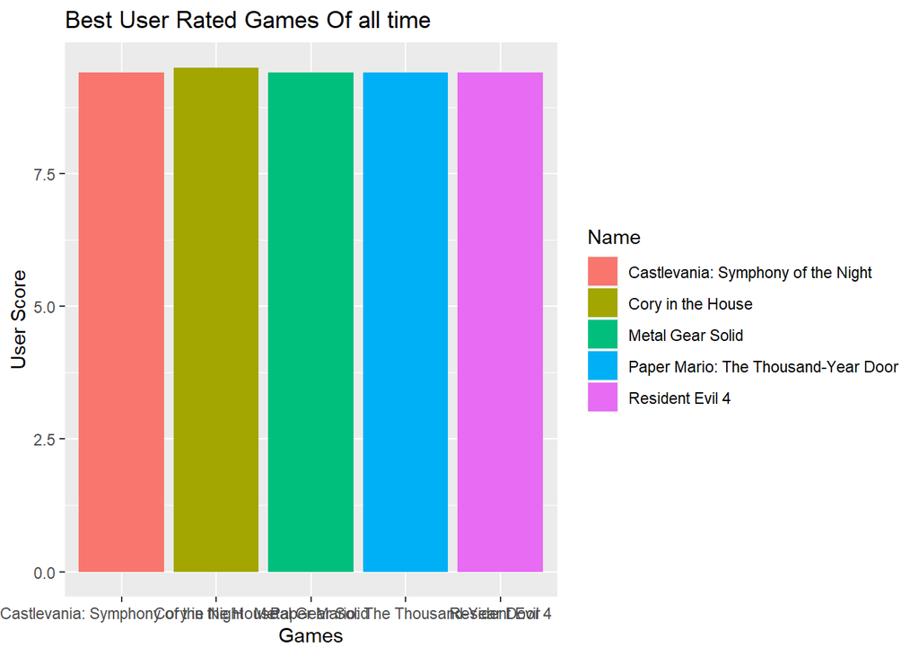

```r
ggplot(data = Top_Ranked_Games_By_User) + geom_col(mapping = aes(x=Name,y=User_Score, fill=Name)) + labs(title = "Best User Rated Games Of all time", x="Games", y = "User Score")
```

```r
Top_Ranked_Games_By_Critics <- Video_Games
Top_Ranked_Games_By_Critics <- arrange(Top_Ranked_Games_By_Critics, desc(Critic_Score))
Top_Ranked_Games_By_Critics <- head(Top_Ranked_Games_By_Critics,5)
head(Top_Ranked_Games_By_Critics,5)
```

```
##                       Name Platform Year_of_Release    Genre
## 1      Grand Theft Auto IV     X360            2008   Action
## 2      Grand Theft Auto IV      PS3            2008   Action
## 3 Tony Hawk's Pro Skater 2       PS            2000   Sports
## 4              SoulCalibur       DC            1999 Fighting
## 5       Grand Theft Auto V      PS3            2013   Action
##              Publisher NA_Sales EU_Sales JP_Sales Other_Sales Global_Sales
## 1 Take-Two Interactive     6.76     3.07     0.14        1.03        11.01
## 2 Take-Two Interactive     4.76     3.69     0.44        1.61        10.50
## 3           Activision     3.05     1.41     0.02        0.20         4.68
## 4   Namco Bandai Games     0.00     0.00     0.34        0.00         0.34
## 5 Take-Two Interactive     7.02     9.09     0.98        3.96        21.04
##   Critic_Score Critic_Count User_Score User_Count               Developer
## 1           98           86        7.9       2951          Rockstar North
## 2           98           64        7.5       2833          Rockstar North
## 3           98           19        7.7        299 Neversoft Entertainment
## 4           98           24        8.8        200                   Namco
## 5           97           50        8.2       3994          Rockstar North
##   Rating
## 1      M
## 2      M
## 3      T
## 4      T
## 5      M
```

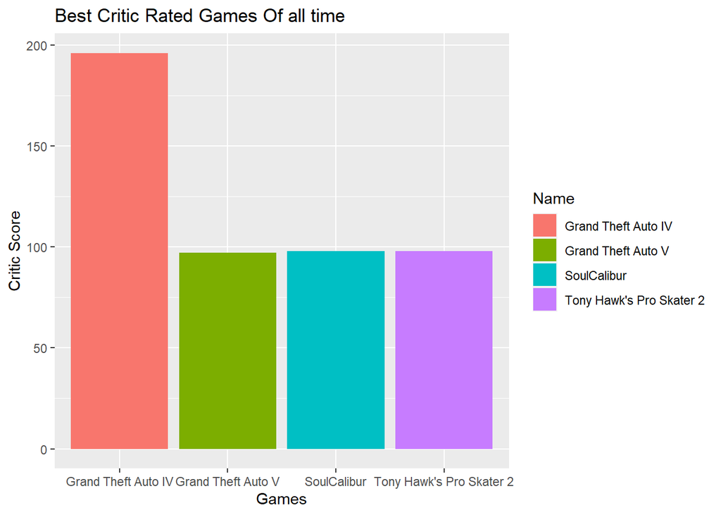

```r
ggplot(data = Top_Ranked_Games_By_Critics) + geom_col(mapping = aes(x=Name,y=Critic_Score, fill=Name)) + labs(title = "Best Critic Rated Games Of all time", x="Games", y = "Critic Score")
```

A quick recap, again: 1. Best selling Platform of all time.(the platform that has sold the most games) **DONE** 2. Best selling game per Platform. **DONE** 3. Best selling Genres. **DONE** 4. Best selling games in those Genres. **DONE** 5. Best User Scored Game. **DONE** 6. Best Critic’s Scored Game. **DONE** 7. Most Sold Video game of all time.

## Now It is time for the Game of the Century.

For the G.O.T.C, It’s easy, the data we have to take in account is the Global sales,

```r
GOTC <- Video_Games
GOTC <- head(arrange(Video_Games, desc(Global_Sales)),5)
head(arrange(Video_Games, desc(Global_Sales)),5)
```

```
##                       Name Platform Year_of_Release        Genre Publisher
## 1               Wii Sports      Wii            2006       Sports  Nintendo
## 2        Super Mario Bros.      NES            1985     Platform  Nintendo
## 3           Mario Kart Wii      Wii            2008       Racing  Nintendo
## 4        Wii Sports Resort      Wii            2009       Sports  Nintendo
## 5 Pokemon Red/Pokemon Blue       GB            1996 Role-Playing  Nintendo
##   NA_Sales EU_Sales JP_Sales Other_Sales Global_Sales Critic_Score Critic_Count
## 1    41.36    28.96     3.77        8.45        82.53           76           51
## 2    29.08     3.58     6.81        0.77        40.24           NA           NA
## 3    15.68    12.76     3.79        3.29        35.52           82           73
## 4    15.61    10.93     3.28        2.95        32.77           80           73
## 5    11.27     8.89    10.22        1.00        31.37           NA           NA
##   User_Score User_Count Developer Rating
## 1        8.0        322  Nintendo      E
## 2         NA         NA
## 3        8.3        709  Nintendo      E
## 4        8.0        192  Nintendo      E
## 5         NA         NA
```

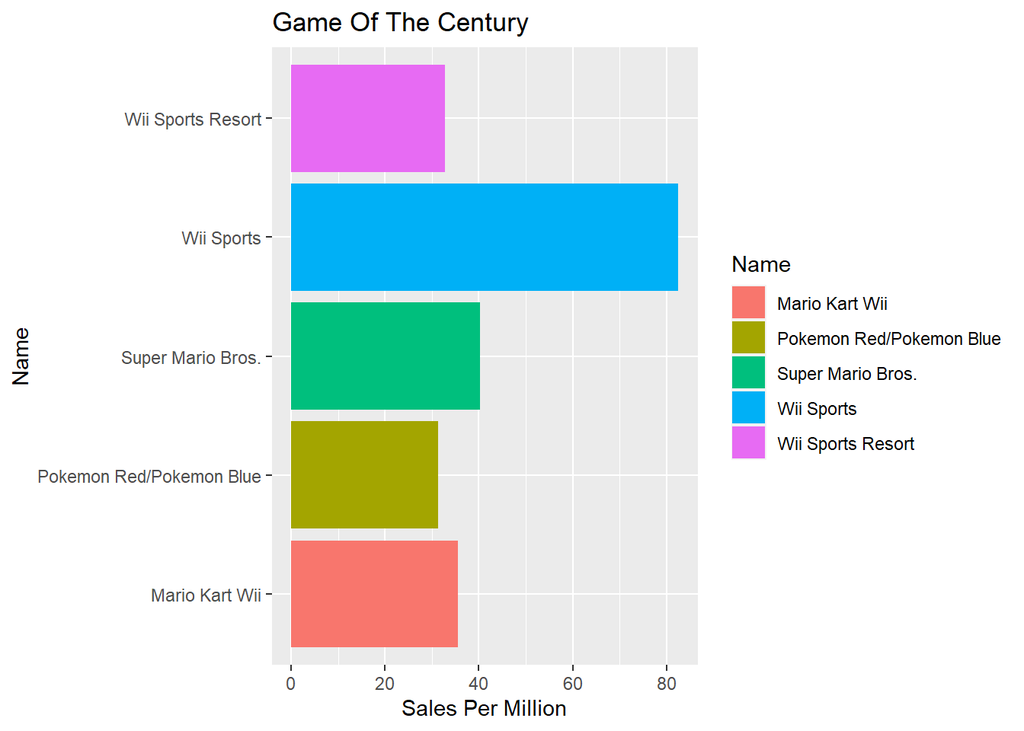

```r
ggplot(data = GOTC) + geom_col(mapping = aes(x=Global_Sales,y=Name, fill=Name)) + labs(title = "Game Of The Century", x="Sales Per Million", y = "Name")
```

## And the Game of the century is…“Drum roll”…**Wii sports**

A quick Project recap. This is my first project of many, It was really fun trying new things, seeing that something did not work and trying to find a new way to fix it. I hope you had as much fun as I did and learned as much as I did, like that the Best seller in the Shooter Category was Duck hunt…I did not expect that. Thank you again and hope to see you again!